# Module 1 Data wrangling

## Libraries

**Show R code**

```r
library(tidyverse)
library(skimr)
library(janitor)
```

## Set directories

Make sure to use a single /, or two \\, since R interprets a single \ as an escape character

**Show R code**

```r
main_dir <- "G:/My Drive/Linked data course/Short course Feburary 2026/Module 1"

data_dir <- file.path(main_dir, "Data")
analysis_dir <- file.path(main_dir, "Analysis")
results_dir <- file.path(main_dir, "Tables and figures")
```

## Read in raw data

We have two datasets to read in.

The first dataset is ‘anzdata_patients.csv’. This includes all patients who commenced kidney replacement therapy at St Vincent’s Hospital Sydney, 2015-2019. The variables provided are:

- ppn (ID)
- age
- sex
- date (Date started kidney replacement therapy)

The second dataset is ‘anzdata_transplants.csv’. This includes all kidney transplants performed in NSW, 2015-2024. The variables provided are:

- ppn (ID)
- graftno (Transplant sequence number)
- date (Date of kidney transplant)
- txtype (Deceased vs. living donor transplant)

Use read_csv() instead of read.csv() to read in data as a ‘tibble’

````markdown
```{r}
anzdata_patients <- read_csv(file.path(main_dir, paste0("anzdata_patients", ".csv")))
anzdata_transplants <- read_csv(file.path(main_dir, paste0("anzdata_transplants", ".csv")))
```
````

You can also read in the data directly from the github

**Show R code**

```r
anzdata_patients <- read_csv("https://raw.githubusercontent.com/NicoleDeLaMata/LinkedData/refs/heads/main/anzdata_patients.csv")
anzdata_transplants <- read_csv("https://raw.githubusercontent.com/NicoleDeLaMata/LinkedData/refs/heads/main/anzdata_transplants.csv")
```

## Data checks

### ANZDATA patients

**Show R code**

```r
# Check number of records, columns, and data types
anzdata_patients
```

```
# A tibble: 157 × 4
   ppn              age sex    date
   <chr>          <dbl> <chr>  <date>
 1 PPN02899298367    68 Male   2015-01-06
 2 PPN05783565645    49 Male   2015-02-10
 3 PPN04546925702    38 Female 2015-02-27
 4 PPN03223760190    69 Female 2015-02-28
 5 PPN09335369272    75 Male   2015-03-11
 6 PPN07556327197    38 Male   2015-03-13
 7 PPN06521771457    72 Male   2015-03-17
 8 PPN02615124995    27 Male   2015-04-12
 9 PPN02473714526    14 Female 2015-04-14
10 PPN05565220881    68 Male   2015-04-18
# ℹ 147 more rows
```

There are 157 rows (records) and 4 columns (variables)

- ppn is a character string
- age is numeric (with double floating point precision, i.e. ~16 significant figures)
- sex is a character string
- date is a date

**Show R code**

```r
# Quick overview - check missing data
anzdata_patients %>% skim()
```

Data summary

| Name | Piped data |
| --- | --- |
| Number of rows | 157 |
| Number of columns | 4 |
| _______________________ |  |
| Column type frequency: |  |
| character | 2 |
| Date | 1 |
| numeric | 1 |
| ________________________ |  |
| Group variables | None |

**Variable type: character**

| skim_variable | n_missing | complete_rate | min | max | empty | n_unique | whitespace |
| --- | --- | --- | --- | --- | --- | --- | --- |
| ppn | 0 | 1 | 14 | 14 | 0 | 157 | 0 |
| sex | 0 | 1 | 4 | 6 | 0 | 2 | 0 |

**Variable type: Date**

| skim_variable | n_missing | complete_rate | min | max | median | n_unique |
| --- | --- | --- | --- | --- | --- | --- |
| date | 0 | 1 | 2015-01-06 | 2019-12-14 | 2017-05-13 | 150 |

**Variable type: numeric**

| skim_variable | n_missing | complete_rate | mean | sd | p0 | p25 | p50 | p75 | p100 | hist |
| --- | --- | --- | --- | --- | --- | --- | --- | --- | --- | --- |
| age | 0 | 1 | 57.04 | 20.13 | 2 | 44 | 60 | 73 | 89 | ▂▂▇▇▇ |

There is no missing data

**Show R code**

```r
# Table for categorical variables
anzdata_patients %>%
  tabyl(sex)
```

```
    sex   n   percent
 Female  51 0.3248408
   Male 106 0.6751592
```

- 51 females (32%)
- 106 males (68%)

**Show R code**

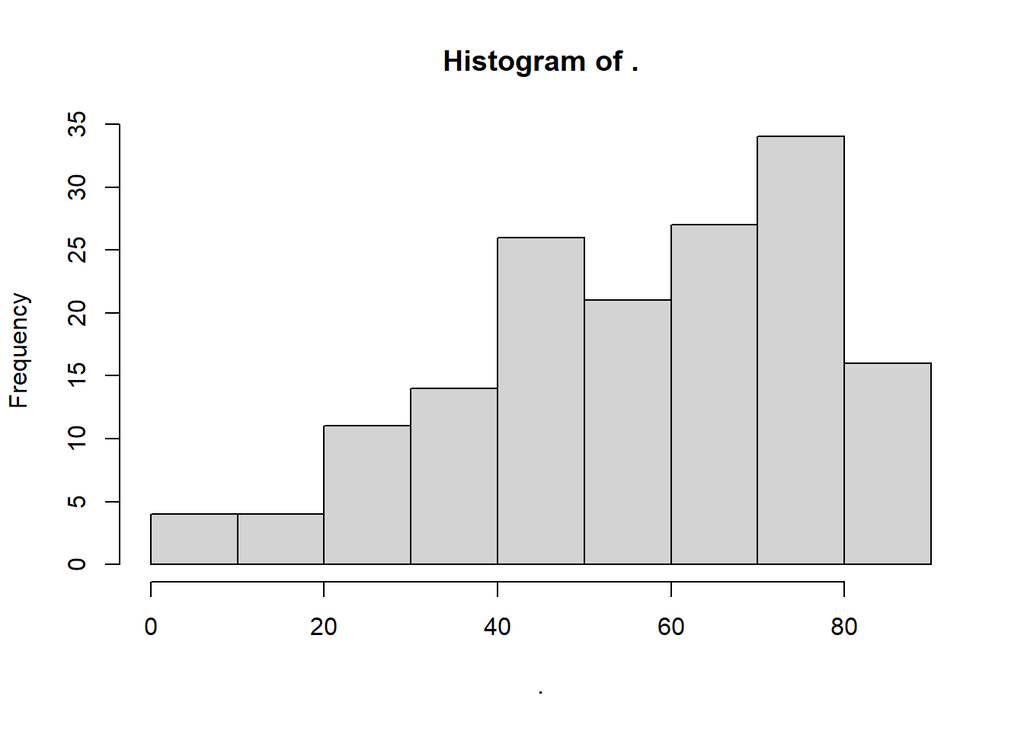

```r
# Histograms for continuous variables
anzdata_patients %>% pull(age) %>% hist()
```

Patients are mostly older, median age is 60

**Show R code**

```r
# Check range for dates
anzdata_patients %>% skim(date)
```

Data summary

| Name | Piped data |
| --- | --- |
| Number of rows | 157 |
| Number of columns | 4 |
| _______________________ |  |
| Column type frequency: |  |
| Date | 1 |
| ________________________ |  |
| Group variables | None |

**Variable type: Date**

| skim_variable | n_missing | complete_rate | min | max | median | n_unique |
| --- | --- | --- | --- | --- | --- | --- |
| date | 0 | 1 | 2015-01-06 | 2019-12-14 | 2017-05-13 | 150 |

Dates span from 6th Jan 2015 to 14th Dec 2019. This matches what we know, i.e. the data covers all patients from 2015 to 2019

### ANZDATA transplants

**Show R code**

```r
# Check data types
anzdata_transplants
```

```
# A tibble: 2,223 × 4
          ppn graftno date       txtype
        <dbl>   <dbl> <date>     <chr>
 1  326543177       1 2019-05-11 Deceased
 2  326543177       2 2020-01-31 Deceased
 3  396129623       1 2020-04-29 Deceased
 4  396129623       2 2023-12-16 Deceased
 5 1010159219       2 2020-05-23 Living
 6 1338216927       1 2021-12-12 Deceased
 7 5516420253       1 2019-03-22 Deceased
 8 5516420253       2 2022-08-06 Deceased
 9 9723983795       1 2022-01-12 Deceased
10 3540792637       1 2018-02-18 Deceased
# ℹ 2,213 more rows
```

**Show R code**

```r
# Overview summary
anzdata_transplants %>% skim()
```

Data summary

| Name | Piped data |
| --- | --- |
| Number of rows | 2223 |
| Number of columns | 4 |
| _______________________ |  |
| Column type frequency: |  |
| character | 1 |
| Date | 1 |
| numeric | 2 |
| ________________________ |  |
| Group variables | None |

**Variable type: character**

| skim_variable | n_missing | complete_rate | min | max | empty | n_unique | whitespace |
| --- | --- | --- | --- | --- | --- | --- | --- |
| txtype | 0 | 1 | 6 | 8 | 0 | 2 | 0 |

**Variable type: Date**

| skim_variable | n_missing | complete_rate | min | max | median | n_unique |
| --- | --- | --- | --- | --- | --- | --- |
| date | 0 | 1 | 2015-01-01 | 2024-12-27 | 2020-10-24 | 1634 |

**Variable type: numeric**

| skim_variable | n_missing | complete_rate | mean | sd | p0 | p25 | p50 | p75 | p100 | hist |
| --- | --- | --- | --- | --- | --- | --- | --- | --- | --- | --- |
| ppn | 0 | 1 | 4.990096e+09 | 2.871661e+09 | 10977762 | 2516104982 | 4950151811 | 7531051130 | 9995017317 | ▇▇▇▇▇ |
| graftno | 0 | 1 | 1.020000e+00 | 1.500000e-01 | 1 | 1 | 1 | 1 | 3 | ▇▁▁▁▁ |

**Show R code**

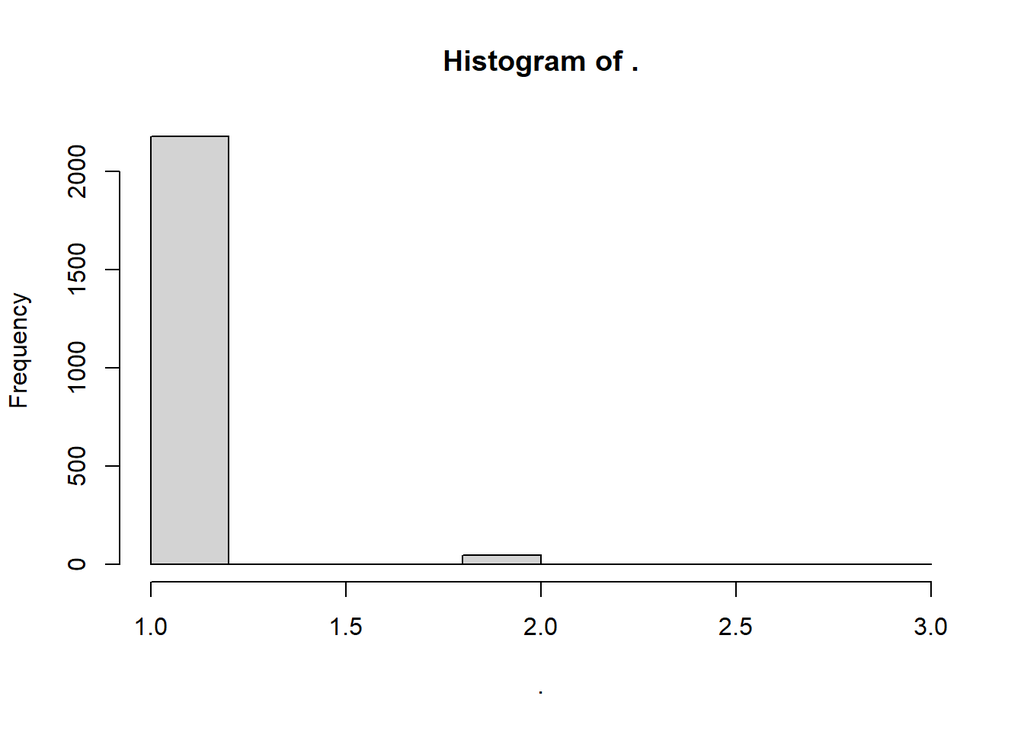

```r
# Histogram for graftno
anzdata_transplants %>% pull(graftno) %>% hist()
```

**Show R code**

```r
# Table for graftno
anzdata_transplants %>% tabyl(graftno)
```

```
 graftno    n      percent
       1 2176 0.9788573999
       2   46 0.0206927575
       3    1 0.0004498426
```

**Show R code**

```r
# Table for transplant type
anzdata_transplants %>% tabyl(txtype)
```

```
   txtype    n  percent
 Deceased 1442 0.648673
   Living  781 0.351327
```

**Show R code**

```r
# Check range for dates
anzdata_transplants %>% skim(date)
```

Data summary

| Name | Piped data |
| --- | --- |
| Number of rows | 2223 |
| Number of columns | 4 |
| _______________________ |  |
| Column type frequency: |  |
| Date | 1 |
| ________________________ |  |
| Group variables | None |

**Variable type: Date**

| skim_variable | n_missing | complete_rate | min | max | median | n_unique |
| --- | --- | --- | --- | --- | --- | --- |
| date | 0 | 1 | 2015-01-01 | 2024-12-27 | 2020-10-24 | 1634 |

There are 2,223 rows (records) and 4 columns (variables)

There is no missing data

Most transplants have graftno = 1, i.e. they are the first transplant for that patient

- 2,176 transplants were the first transplant for that patient
- 46 transplants were the second transplant for that patient
- 1 transplant was the third transplant for that patient

There are two transplant types:

- 1,442 (65%) transplants came from a deceased donor
- 781 (35%) transplants came from a living donor

The transplant dates range from 1st Jan 2015 to 27th Dec 2024

**Show R code**

```r
# Manually check some examples where graftno != 1
anzdata_transplants %>% filter(graftno != 1)
```

```
# A tibble: 47 × 4
          ppn graftno date       txtype
        <dbl>   <dbl> <date>     <chr>
 1  326543177       2 2020-01-31 Deceased
 2  396129623       2 2023-12-16 Deceased
 3 1010159219       2 2020-05-23 Living
 4 5516420253       2 2022-08-06 Deceased
 5 2726922079       2 2024-07-25 Deceased
 6 4738963497       2 2023-08-01 Deceased
 7 5986930236       2 2020-08-05 Living
 8 1359430963       2 2022-11-18 Deceased
 9 2615124995       2 2022-10-17 Deceased
10 1509465340       2 2020-09-20 Deceased
# ℹ 37 more rows
```

**Show R code**

```r
# Check if first few people have any other records
anzdata_transplants %>% filter(ppn == 326543177)
```

```
# A tibble: 2 × 4
        ppn graftno date       txtype
      <dbl>   <dbl> <date>     <chr>
1 326543177       1 2019-05-11 Deceased
2 326543177       2 2020-01-31 Deceased
```

**Show R code**

```r
anzdata_transplants %>% filter(ppn == 396129623)
```

```
# A tibble: 2 × 4
        ppn graftno date       txtype
      <dbl>   <dbl> <date>     <chr>
1 396129623       1 2020-04-29 Deceased
2 396129623       2 2023-12-16 Deceased
```

**Show R code**

```r
anzdata_transplants %>% filter(ppn == 1010159219)
```

```
# A tibble: 1 × 4
         ppn graftno date       txtype
       <dbl>   <dbl> <date>     <chr>
1 1010159219       2 2020-05-23 Living
```

Some people have more than one transplant in this dataset

Some others have only one transplant, but graftno = 2

This is because their first transplant must not have been included in this dataset (not performed in NSW, 2015-2024)

## Data cleaning

Rename ‘date’ to ‘krtstartdate’ to make clear it refers to the date that kidney replacement therapy started

**Show R code**

```r
anzdata_patients_clean <- anzdata_patients %>%
  # Rename date variable
  rename(krtstartdate = date)
```

Rename ‘date’ to ‘txdate’ to make clear it refers to the date of the kidney transplant

Convert PPN to a character string, starting with ‘PPN’, and including leading zeroes (to match how it is stored in anzdata_patients)

**Show R code**

```r
anzdata_transplants_clean <- anzdata_transplants %>%
  # Rename date variable
  rename(txdate = date) %>%
  # Convert PPN to same format as in ANZDATA patients
  mutate(ppn = str_c("PPN", str_pad(ppn, width = 11, pad = "0")))
```

## Merge datasets

**Show R code**

```r
merged_data <- left_join(anzdata_patients_clean,
                         anzdata_transplants_clean,
                         by = "ppn")
```

left_join since we want to keep all of the records in anzdata_patients, and look up their corresponding transplant information from anzdata_transplants

Since some people can have more than one transplant, this is a 1-to-many merge. Each PPN appears exactly once in the left-hand dataset (anzdata_patients). But each PPN can potentially appear more than once (many times) in the right-hand dataset (anzdata_transplants)

The merged dataset will therefore contain multiple rows per person, one row for each transplant

**Show R code**

```r
# Answer our original question
merged_data %>% tabyl(graftno)
```

```
 graftno   n     percent valid_percent
       1  32 0.202531646    0.96969697
       2   1 0.006329114    0.03030303
      NA 125 0.791139241            NA
```

There were 33 transplants performed in total

- 32 patients received at least one transplants (graftno = 1)
- 1 patient received two transplants (graftno = 2)

Therefore, 32 - 1 = 31 patients received one transplant, and 1 patient received two

So 32 patients received a transplant during our follow-up period.